# 36-402: Exam 1

# Outliers

Below are the Rstudent and Cook’s Distance plots of our initial model. There are a few worrisome points, having Cook’s Distance greater than 0.05 and Rstudent above 2: Albania in 1800 where urbanization quadruples, Belgium post Black Plague (1400), where urbanization triples and England in 1850 where population doubles. A cursory glance of history does not reveal much about changes in Albania in 1800, however its Cook’s Distance is abnormally large and we will therefore remove it. There are ties between urbanization and the Black Plague. The Industrial Revolution begins in Britain in the 1800’s and thus should explains its outlier status. Those three points have been removed and the model rerun.

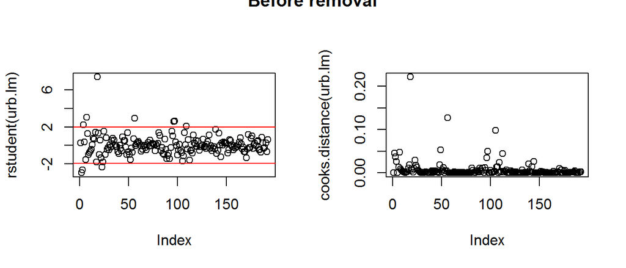

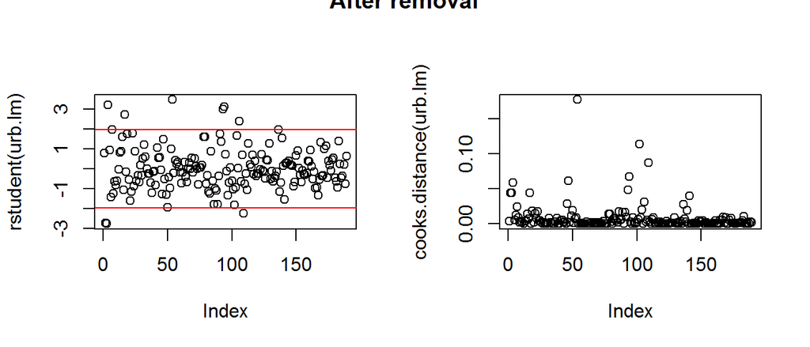

## Residuals

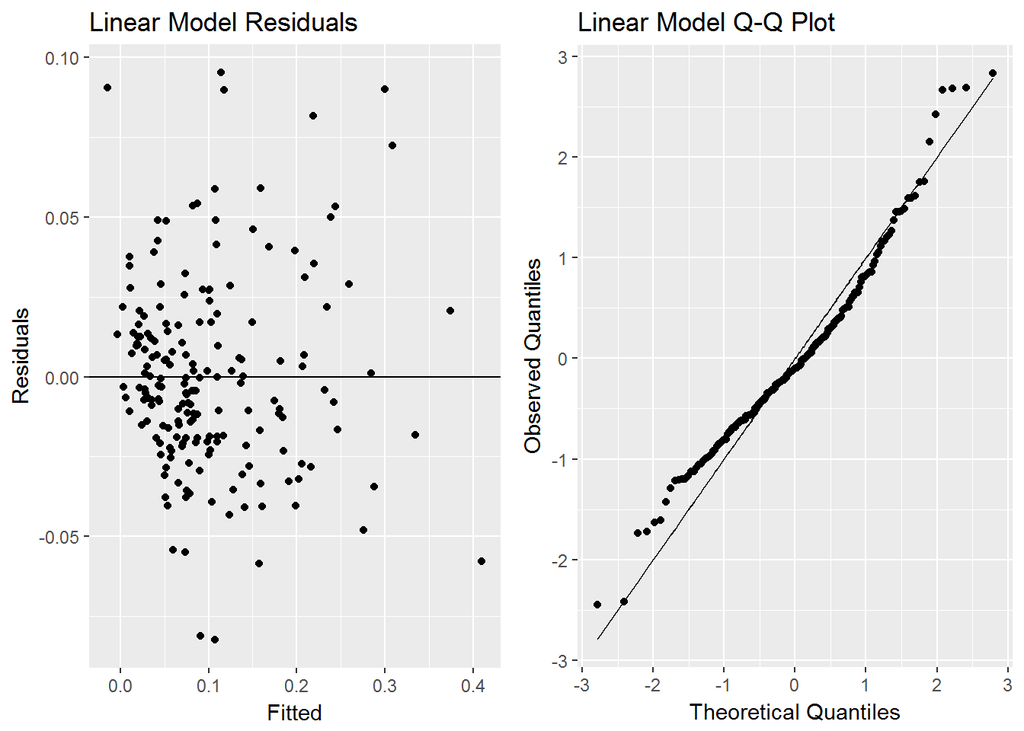

```r
urb.lm.resid <- residuals(urb.lm)
urb.lm.fit <- fitted(urb.lm)
urb.lm.df <- data.frame(Residuals = urb.lm.resid, Fitted = urb.lm.fit)
#QQPlot of Residuals
urb.lm.sd <- sqrt(deviance(urb.lm)/df.residual(urb.lm))
urb.lm.residSD <- urb.lm$residuals/urb.lm.sd

lm.res <- ggplot(urb.lm.df) +
                 geom_point(aes(Fitted, Residuals)) +
                 xlab('Fitted') +
                 ylab('Residuals') +
                 geom_hline(aes(yintercept = 0)) +
                 ggtitle("Linear Model Residuals")


#Plot the qqplot of the Sd's
lm.qq <- ggplot() + geom_point(aes(qnorm(ppoints(urb.lm.residSD)),
                                    sort(urb.lm.residSD))) +
                     xlab('Theoretical Quantiles') +
                     ylab('Observed Quantiles') +
                     geom_line(aes(qnorm(ppoints(urb.lm.residSD)),
                                   qnorm(ppoints(urb.lm.residSD)))) +
                     ggtitle("Linear Model Q-Q Plot")

grid.arrange(lm.res, lm.qq, nrow = 1)
```

## Mean Squared Error

```r
#Professors Code
cv.model <- function(data, model, formulae, nfolds=5) {
  data <- na.omit(data)
  formulae <- sapply(formulae, as.formula)
  n <- nrow(data)
  fold.labels <- sample(rep(1:nfolds, length=n))
  mses <- matrix(NA, nrow=nfolds, ncol=length(formulae))
  colnames <- as.character(formulae)
  for (fold in 1:nfolds) {
    test.rows <- which(fold.labels == fold)
    train <- data[-test.rows,]
    test <- data[test.rows,]
    for (form in 1:length(formulae)) {
       current.model <- model(formula=formulae[[form]], data=train)
       predictions <- predict(current.model, newdata=test)
       test.responses <- eval(formulae[[form]][[2]], envir=test)
       test.errors <- test.responses - predictions
       mses[fold, form] <- mean(test.errors^2)
    }
  }
  return(colMeans(mses))
}

mse.lm <- cv.model(raj, lm, "urbanization ~ factor(country) + factor(year) +
                                 factor(westernEurope) + (atlTrade:coastToArea) +
                                 ordered(initialConstr) +
                                 ordered(initialConstr):atlTrade:coastToArea")
```

Instead of returnung the simple mean squared error, we felt it would be better suited to cross validate the mean squared error. Using 5-fold cross validation, our algorithm returns a mean squared error of 0.0015457.

# Secondary Modeling

## Introduction

After testing a few different models, We chose to use a generalized linear model with different variables and interactions.

## Decision Trees

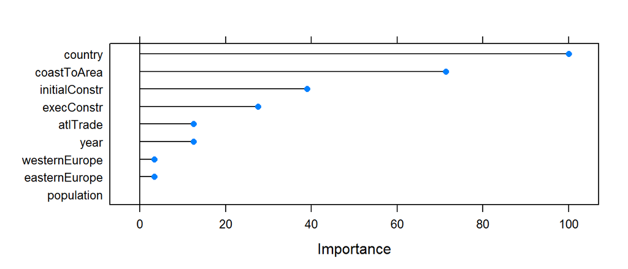

```r
#Decision Tree
set.seed(100)

urb.tree <- train(urbanization ~ ., data = raj,
                      method = "ctree",
                      trControl = trainControl(method = "cv", number = 5),
                      tuneGrid = expand.grid(mincriterion = 0.95))

#Plotting important variables
plot(varImp(urb.tree))
```

# Testing Models

We tested a few different models cross-validated mean squared errors and chose the one with the smallest value. Below are the ones we tested.

```r
tm1 <- cv.model(raj, glm, "urbanization ~ factor(year) +
                                 (atlTrade:coastToArea) +
                                 ordered(initialConstr) +
                                 ordered(initialConstr):atlTrade:coastToArea")

tm2 <- cv.model(raj, glm, "urbanization ~ factor(country) +
                                 (atlTrade:coastToArea) +
                                 ordered(initialConstr) +
                                 ordered(initialConstr):atlTrade:coastToArea")

tm3 <- cv.model(raj, glm, "urbanization ~ factor(country) +
                                 (atlTrade:coastToArea) +
                                 ordered(initialConstr):atlTrade:coastToArea")

tm4 <- cv.model(raj, glm, "urbanization ~ factor(country) +
                                 (atlTrade:coastToArea) +
                                 ordered(initialConstr):atlTrade")
```